# Math 189: Logistic Regression II

# Multiple Logistic Regression

- Goal: predict a binary response using multiple predictors.
- We generalize the previous model as follows:
  $$\log \left( \frac{ p( \underline{X})}{ 1- p (\underline{X})} \right)
  = \beta_0 + \beta_1 X_1 + \ldots + \beta_p X_p$$
  where is $\underline{X}$ is a $p$-vector of covariates.
- Equivalently,
  $$p( \underline{X}) = \frac{ \exp \{ \beta_0 + \beta_1 X_1 + \ldots + \beta_p X_p \} }{
  1 + \exp \{ \beta_0 + \beta_1 X_1 + \ldots + \beta_p X_p \} }$$
- Let $\underline{\beta} = {[ \beta_1, \ldots, \beta_p ]}^{\prime}$ be the vector of regression coefficients; $\beta_0$ is referred to as the intercept.

## Logistic Function

- Set the logistic function to be
  $$\phi (t) = \frac{1}{1 + e^{-t}}$$
- Then the logistic regression model for ${(Y,\underline{X})}$ is
  $$p( \underline{x}) = {\mathbb P} [ Y = 1 \vert \underline{X} = \underline{x} ]
  = \phi ( \beta_0 + \underline{x}^{\prime} \underline{\beta})$$
- On the other hand
  $${\mathbb P} [ Y = 0 \vert \underline{X} = \underline{x} ]
  = 1 - \phi ( \beta_0 + \underline{x}^{\prime} \underline{\beta})$$

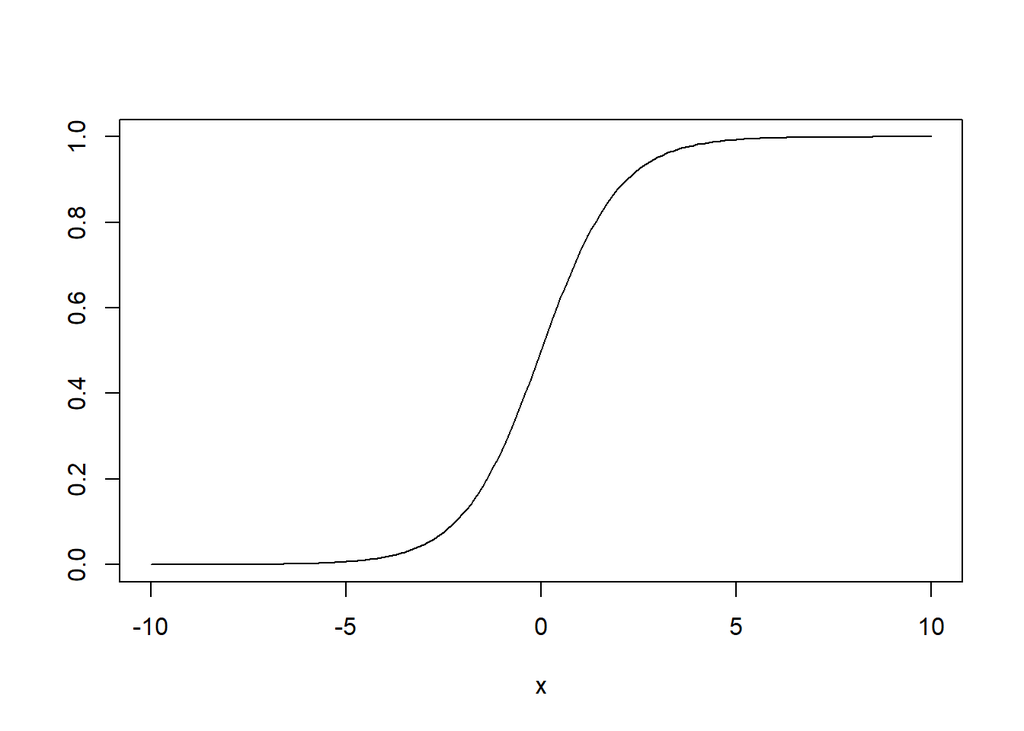

```r
x <- seq(-10,10,.1)
y <- (1+exp(-x))^{-1}
plot(ts(y,start=-10,frequency=10),xlab="x",ylab="")
```

## Likelihood Function

- To compute the likelihood function, assume that $(Y_1, \underline{X}_1),\ldots,(Y_n,\underline{X}_n)$ are i.i.d.
- The conditional density of $Y_i$ given $\underline{X}_i$ is
  $${ \left( \phi ( \beta_0 + \underline{X}_i^{\prime} \underline{\beta} ) \right)}^{Y_i}
  \, { \left( 1 - \phi ( \beta_0 + \underline{X}_i^{\prime}
  \underline{\beta} ) \right)}^{1 - Y_i}$$
  Hence, the joint density of $Y_1, \ldots, Y_n$ given $\underline{X}_1, \ldots,\underline{X}_n$ is
  $$L_n (\beta_0, \underline{\beta} ) = \prod_{i=1}^n { \left( \phi ( \beta_0 + \underline{X}_i^{\prime} \underline{\beta} ) \right)}^{Y_i}
  \, { \left( 1 - \phi ( \beta_0 + \underline{X}_i^{\prime}
  \underline{\beta} ) \right)}^{1 - Y_i}$$
  This $L_n: {\mathbb R}^{p+1} \rightarrow [0,\infty)$ is called the *likelihood function*.

## Maximum Likelihood Estimator

- The *maximum likelihood estimator* $(\widehat{\beta}_0, \widehat{\underline{\beta}})$ is defined as the maximizer of the likelihood function:
  $$(\widehat{\beta}_0, \widehat{\underline{\beta}}) = \arg \max
  L_n (\beta_0, \underline{\beta} )$$
- In both theory and practice, it is easier to work with the logarithm of the likelihood function.
  $$\mathcal{L}_n (\beta_0, \underline{\beta} ) = \log L_n (\beta_0, \underline{\beta} )
  = \sum_{i=1}^n \left\{ Y_i \, \log \left( \phi ( \beta_0 + \underline{X}_i^{\prime} \underline{\beta} ) \right) + (1 - Y_i) \log \left( 1 - \phi ( \beta_0 + \underline{X}_i^{\prime} \underline{\beta} ) \right) \right\}$$

### Example: Default Data

- Consider Default data. Let $X_1$ be balance, $X_2$ be income, $X_3 \in \{ 0, 1 \}$ is student status.

```r
library(ISLR)
data(Default)
y <- as.numeric(Default$default=="Yes")
stu <- as.numeric(Default$student=="Yes")
income <- 0.001*Default$income
balance <- Default$balance
all.fit <- glm(y~stu+balance+income,data=Default,family=binomial)
summary(all.fit)
```

```
##
## Call:
## glm(formula = y ~ stu + balance + income, family = binomial,
##     data = Default)
##
## Deviance Residuals:
##     Min       1Q   Median       3Q      Max
## -2.4691  -0.1418  -0.0557  -0.0203   3.7383
##
## Coefficients:
##               Estimate Std. Error z value Pr(>|z|)
## (Intercept) -1.087e+01  4.923e-01 -22.080  < 2e-16 ***
## stu         -6.468e-01  2.363e-01  -2.738  0.00619 **
## balance      5.737e-03  2.319e-04  24.738  < 2e-16 ***
## income       3.033e-06  8.203e-06   0.370  0.71152
## ---
## Signif. codes:  0 '***' 0.001 '**' 0.01 '*' 0.05 '.' 0.1 ' ' 1
##
## (Dispersion parameter for binomial family taken to be 1)
##
##     Null deviance: 2920.6  on 9999  degrees of freedom
## Residual deviance: 1571.5  on 9996  degrees of freedom
## AIC: 1579.5
##
## Number of Fisher Scoring iterations: 8
```

- We can make predictions by plugging in the coefficient estimates:
  $$\widehat{p}( \underline{x}) =
  \phi ( \widehat{\beta}_0 + \underline{x}^{\prime} \widehat{\underline{\beta}})$$

```r
pred_all <- function(obs){
  x <- c(1,obs)
  pred <- as.numeric(as.numeric(x %*% all.fit$coefficients))
  pred <- 1/(1+exp(-pred))
  return(pred)
}
```

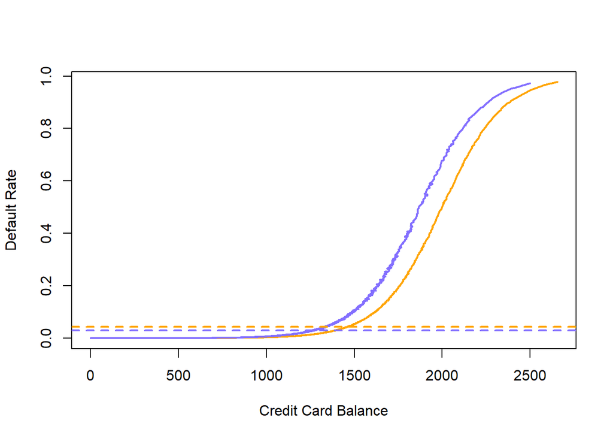

```r
fitted.prob <- as.numeric(all.fit$fitted.values)
prob.stu <- fitted.prob[stu==1]
balance.stu <- balance[stu==1]
M1 <- matrix(c(prob.stu,balance.stu), ncol = 2)
M1 <- M1[order(M1[,1], decreasing = FALSE),]

plot(M1[,2], M1[,1],type='l',lwd=2,col="orange",
     xlab="Credit Card Balance",ylab="Default Rate")

prob.nonstu <- fitted.prob[stu==0]
balance.nonstu <- balance[stu==0]
M2 <- matrix(c(prob.nonstu,balance.nonstu), ncol = 2)
M2 <- M2[order(M2[,1], decreasing = FALSE),]

lines(M2[,2],M2[,1],lwd=2,col="slateblue1")

stu.rate <- sum(stu[y==1])/sum(stu)
nonstu.rate <- sum((1-stu)[y==1])/sum(1-stu)

abline(h=stu.rate,lwd=2,lty=2,col="orange")
abline(h=nonstu.rate,lwd=2,lty=2,col="slateblue1")
```

- We can examine boxplots for Balance as a function of Student status.

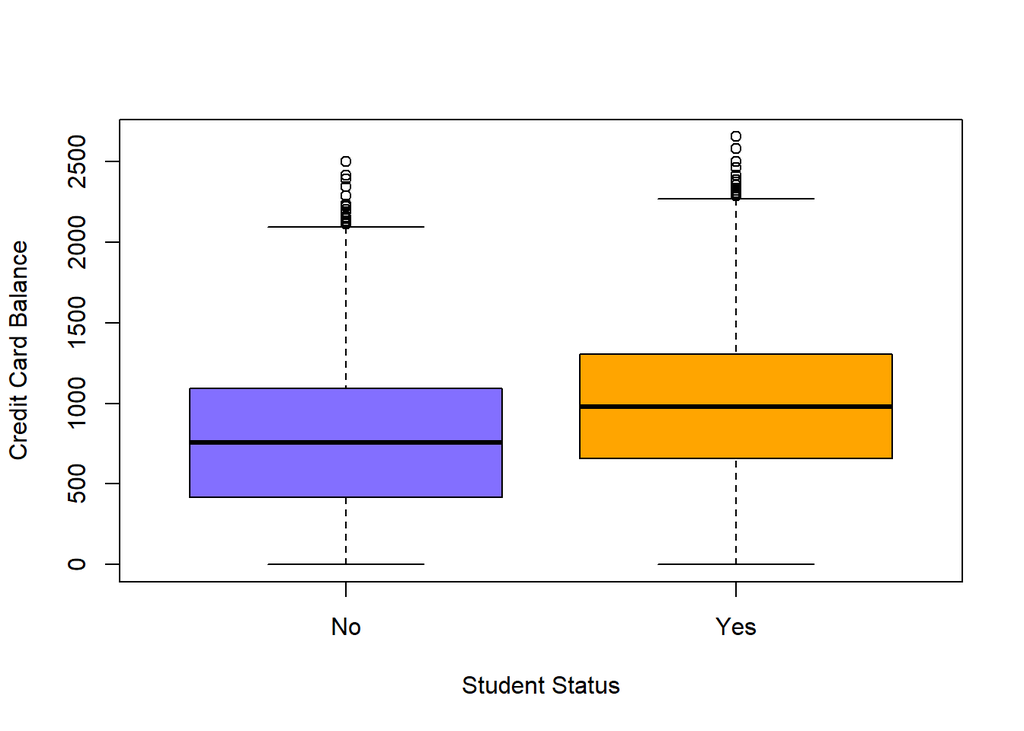

```r
boxplot(balance~Default$student,xlab="Student Status",
        ylab="Credit Card Balance",col=c("slateblue1","orange"))
```